# Path Analysis

Mo’men Mohamed

March 9, 2019

#### First of all lets load all libraries we need in our model building

```r
library(lavaan)
library(knitr)
library(semPlot)
```

#### In this project i will work on the data which introduced in **Latent Variable Modeling Using R** Book chapter 2

#### This data to build the model which illustrated in This Picture

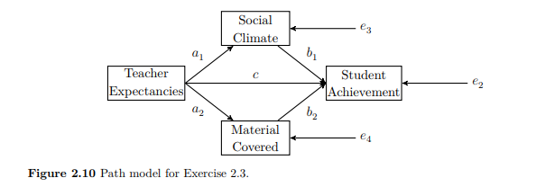

#### The following is the covariance matrix which stated there , and I am going to convert it to matrix to use it in model building

```r
cov<-c(
        84.85,
        71.28,  140.34,
        18.83,  −6.25,  72.92,
        60.05,  84.54,  37.18,  139.48

)

#Convert it to Covariance Matrix

cov<-lav_matrix_lower2full(cov)

#Naming the matrix rows and columns

rownames(cov)<-colnames(cov)<-c("TE","SC","MC","SA")

kable(cov,format = "markdown",align = "c")
```

|  | TE | SC | MC | SA |
| --- | --- | --- | --- | --- |
| TE | 84.85 | 71.28 | 18.83 | 60.05 |
| SC | 71.28 | 140.34 | -6.25 | 84.54 |
| MC | 18.83 | -6.25 | 72.92 | 37.18 |
| SA | 60.05 | 84.54 | 37.18 | 139.48 |

#### Now itis time to specifying the model using lavaan

```r
model<-"
SA ~ b1*SC + b2*MC + c*TE
SC ~ a1*TE
MC ~ a2*TE
ind1:=a1*b1
ind2:=a2*b2
"
```

#### After the specification lets run the model using cfa() function

```r
fit<-cfa(model = model,sample.cov = cov,sample.nobs = 40)
fit.summary<-summary(fit,fit.measures=T,standardized=T)
```

```
## lavaan 0.6-3 ended normally after 17 iterations
##
##   Optimization method                           NLMINB
##   Number of free parameters                          8
##
##   Number of observations                            40
##
##   Estimator                                         ML
##   Model Fit Test Statistic                       3.687
##   Degrees of freedom                                 1
##   P-value (Chi-square)                           0.055
##
## Model test baseline model:
##
##   Minimum Function Test Statistic               58.874
##   Degrees of freedom                                 6
##   P-value                                        0.000
##
## User model versus baseline model:
##
##   Comparative Fit Index (CFI)                    0.949
##   Tucker-Lewis Index (TLI)                       0.695
##
## Loglikelihood and Information Criteria:
##
##   Loglikelihood user model (H0)               -569.656
##   Loglikelihood unrestricted model (H1)       -567.812
##
##   Number of free parameters                          8
##   Akaike (AIC)                                1155.312
##   Bayesian (BIC)                              1168.823
##   Sample-size adjusted Bayesian (BIC)         1143.789
##
## Root Mean Square Error of Approximation:
##
##   RMSEA                                          0.259
##   90 Percent Confidence Interval          0.000  0.564
##   P-value RMSEA <= 0.05                          0.067
##
## Standardized Root Mean Square Residual:
```

[output cut: 15 more lines]

```
##   SC ~
##     TE        (a1)    0.840    0.154    5.456    0.000    0.840    0.653
##   MC ~
##     TE        (a2)    0.222    0.142    1.559    0.119    0.222    0.239
##
## Variances:
##                    Estimate  Std.Err  z-value  P(>|z|)   Std.lv  Std.all
##    .SA               63.323   14.159    4.472    0.000   63.323    0.425
##    .SC               78.448   17.542    4.472    0.000   78.448    0.573
##    .MC               67.023   14.987    4.472    0.000   67.023    0.943
##
## Defined Parameters:
##                    Estimate  Std.Err  z-value  P(>|z|)   Std.lv  Std.all
##     ind1              0.478    0.148    3.229    0.001    0.478    0.356
##     ind2              0.118    0.083    1.421    0.155    0.118    0.088
```

#### In the summary we can see that there is no heywood cases

#### Also after looking to fit measure we can find that CFI (0.949) is very good but we have a srious problem in TLI(0.695) and RMSEA (0.259) with cI (0.000 , 0.564)

#### To diagnose the specify the problem correctly we have to have a look on the parameters to see the following :

##### 1- None significant loading (P > .05) between student acheivement and teacher expectation

##### 2- Also we find that loading between matrial covered and teacher expectation is not significant (P>.05)

##### 3- Finally the mediation effect of Material covered is not significant (P > 0.05)

#### you can find the table & diagram of loadings and Mediation parameter bellow and also fit measures

```r
kable(data.frame(parameterestimates(fit))[-9,],format = "markdown",digits = 3)
```

|  | lhs | op | rhs | label | est | se | z | pvalue | ci.lower | ci.upper |
| --- | --- | --- | --- | --- | --- | --- | --- | --- | --- | --- |
| 1 | SA | ~ | SC | b1 | 0.569 | 0.142 | 4.006 | 0.000 | 0.291 | 0.847 |
| 2 | SA | ~ | MC | b2 | 0.530 | 0.154 | 3.446 | 0.001 | 0.228 | 0.831 |
| 3 | SA | ~ | TE | c | 0.112 | 0.186 | 0.603 | 0.546 | -0.252 | 0.476 |
| 4 | SC | ~ | TE | a1 | 0.840 | 0.154 | 5.456 | 0.000 | 0.538 | 1.142 |
| 5 | MC | ~ | TE | a2 | 0.222 | 0.142 | 1.559 | 0.119 | -0.057 | 0.501 |
| 6 | SA | ~~ | SA |  | 63.323 | 14.159 | 4.472 | 0.000 | 35.571 | 91.075 |
| 7 | SC | ~~ | SC |  | 78.448 | 17.542 | 4.472 | 0.000 | 44.067 | 112.829 |
| 8 | MC | ~~ | MC |  | 67.023 | 14.987 | 4.472 | 0.000 | 37.649 | 96.396 |
| 10 | ind1 | := | a1*b1 | ind1 | 0.478 | 0.148 | 3.229 | 0.001 | 0.188 | 0.768 |
| 11 | ind2 | := | a2*b2 | ind2 | 0.118 | 0.083 | 1.421 | 0.155 | -0.045 | 0.280 |

```r
kable(t(round(data.frame(fitmeasures(fit,fit.measures = c("chisq","df","cfi","tli","rmsea","rmsea.ci.upper","rmsea.ci.lower"))),3)),format = "markdown",row.names = F)
```

| chisq | df | cfi | tli | rmsea | rmsea.ci.upper | rmsea.ci.lower |
| --- | --- | --- | --- | --- | --- | --- |
| 3.687 | 1 | 0.949 | 0.695 | 0.259 | 0.564 | 0 |

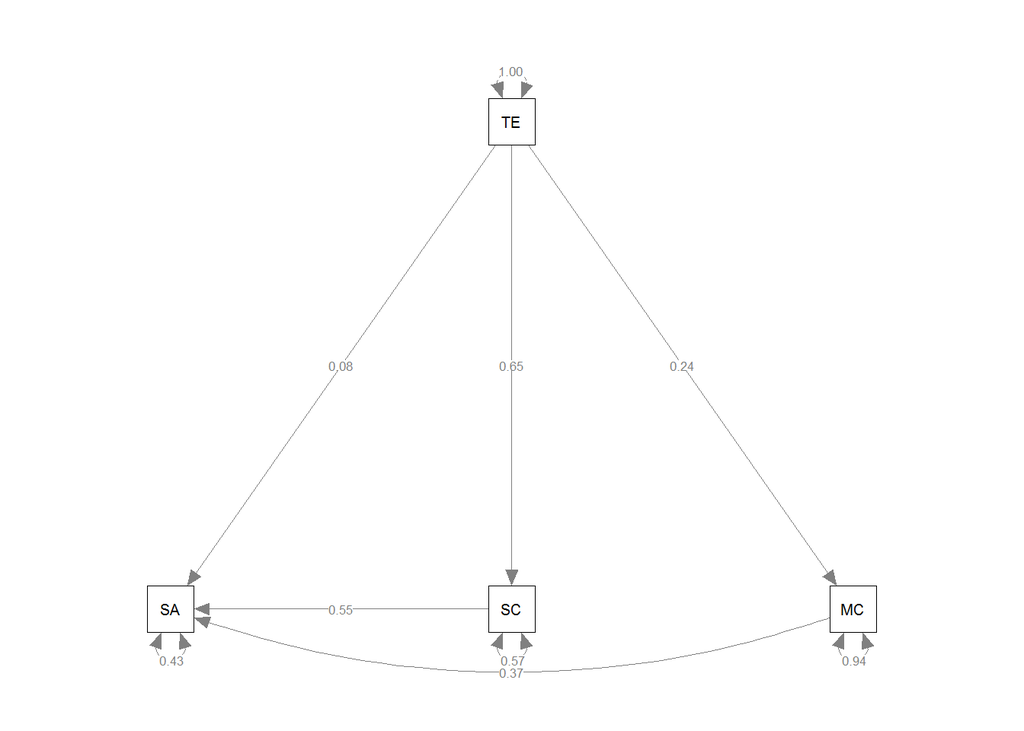

```r
semPlot::semPaths(object = fit,whatLabels = "std",layout = "tree")
```

#### Now I think that it is useful to run some modification on this model

#### So lets inspect the modification indecies first

```r
kable(data.frame(modificationindices(object = fit,sort. = T)),format = "markdown",digits = 3)
```

|  | lhs | op | rhs | mi | epc | sepc.lv | sepc.all | sepc.nox |
| --- | --- | --- | --- | --- | --- | --- | --- | --- |
| 17 | MC | ~ | SA | 3.522 | -0.482 | -0.482 | -0.698 | -0.698 |
| 15 | SC | ~ | SA | 3.522 | -0.606 | -0.606 | -0.632 | -0.632 |
| 16 | SC | ~ | MC | 3.522 | -0.321 | -0.321 | -0.231 | -0.231 |
| 14 | SC | ~~ | MC | 3.522 | -21.517 | -21.517 | -0.297 | -0.297 |
| 18 | MC | ~ | SC | 3.522 | -0.274 | -0.274 | -0.381 | -0.381 |
| 21 | TE | ~ | MC | 0.000 | 0.000 | 0.000 | 0.000 | 0.000 |
| 19 | TE | ~ | SA | 0.000 | 0.000 | 0.000 | 0.000 | 0.000 |
| 20 | TE | ~ | SC | 0.000 | 0.000 | 0.000 | 0.000 | 0.000 |
| 9 | TE | ~~ | TE | 0.000 | 0.000 | 0.000 | 0.000 | 0.000 |

#### See here , the modification index dosen’t add any usefull information , but we can conduct some modification by removing the none signficanat parameters

```r
model2<-"
SA ~ b1*SC + b2*MC
SC ~ a1*TE
ind1:=a1*b1
"
#Run the model

fit2<-cfa(model2,sample.cov = cov,sample.nobs = 40)

summary(fit2,fit.measures=T,standardized=T)
```

```
## lavaan 0.6-3 ended normally after 11 iterations
##
##   Optimization method                           NLMINB
##   Number of free parameters                          5
##
##   Number of observations                            40
##
##   Estimator                                         ML
##   Model Fit Test Statistic                       4.011
##   Degrees of freedom                                 2
##   P-value (Chi-square)                           0.135
##
## Model test baseline model:
##
##   Minimum Function Test Statistic               56.514
##   Degrees of freedom                                 5
##   P-value                                        0.000
##
## User model versus baseline model:
##
##   Comparative Fit Index (CFI)                    0.961
##   Tucker-Lewis Index (TLI)                       0.902
##
## Loglikelihood and Information Criteria:
##
##   Loglikelihood user model (H0)               -569.818
##   Loglikelihood unrestricted model (H1)       -567.812
##
##   Number of free parameters                          5
##   Akaike (AIC)                                1149.636
##   Bayesian (BIC)                              1158.080
##   Sample-size adjusted Bayesian (BIC)         1142.434
##
## Root Mean Square Error of Approximation:
##
##   RMSEA                                          0.159
##   90 Percent Confidence Interval          0.000  0.386
##   P-value RMSEA <= 0.05                          0.162
##
## Standardized Root Mean Square Residual:
```

[output cut: 10 more lines]

```
##                    Estimate  Std.Err  z-value  P(>|z|)   Std.lv  Std.all
##   SA ~
##     SC        (b1)    0.627    0.109    5.739    0.000    0.627    0.597
##     MC        (b2)    0.564    0.152    3.716    0.000    0.564    0.386
##   SC ~
##     TE        (a1)    0.840    0.154    5.456    0.000    0.840    0.653
##
## Variances:
##                    Estimate  Std.Err  z-value  P(>|z|)   Std.lv  Std.all
##    .SA               63.838   14.275    4.472    0.000   63.838    0.422
##    .SC               78.448   17.542    4.472    0.000   78.448    0.573
##
## Defined Parameters:
##                    Estimate  Std.Err  z-value  P(>|z|)   Std.lv  Std.all
##     ind1              0.527    0.133    3.954    0.000    0.527    0.390
```

```r
#drawing the diagram & tabels

kable(data.frame(parameterestimates(fit2))[-c(6,7,8),],format = "markdown",digits = 3)
```

|  | lhs | op | rhs | label | est | se | z | pvalue | ci.lower | ci.upper |
| --- | --- | --- | --- | --- | --- | --- | --- | --- | --- | --- |
| 1 | SA | ~ | SC | b1 | 0.627 | 0.109 | 5.739 | 0 | 0.413 | 0.842 |
| 2 | SA | ~ | MC | b2 | 0.564 | 0.152 | 3.716 | 0 | 0.266 | 0.861 |
| 3 | SC | ~ | TE | a1 | 0.840 | 0.154 | 5.456 | 0 | 0.538 | 1.142 |
| 4 | SA | ~~ | SA |  | 63.838 | 14.275 | 4.472 | 0 | 35.860 | 91.815 |
| 5 | SC | ~~ | SC |  | 78.448 | 17.542 | 4.472 | 0 | 44.067 | 112.829 |
| 9 | ind1 | := | a1*b1 | ind1 | 0.527 | 0.133 | 3.954 | 0 | 0.266 | 0.788 |

```r
kable(t(round(data.frame(fitmeasures(fit2,fit.measures = c("chisq","df","cfi","tli","rmsea","rmsea.ci.upper","rmsea.ci.lower"))),3)),format = "markdown",row.names = F)
```

| chisq | df | cfi | tli | rmsea | rmsea.ci.upper | rmsea.ci.lower |
| --- | --- | --- | --- | --- | --- | --- |
| 4.011 | 2 | 0.961 | 0.902 | 0.159 | 0.386 | 0 |

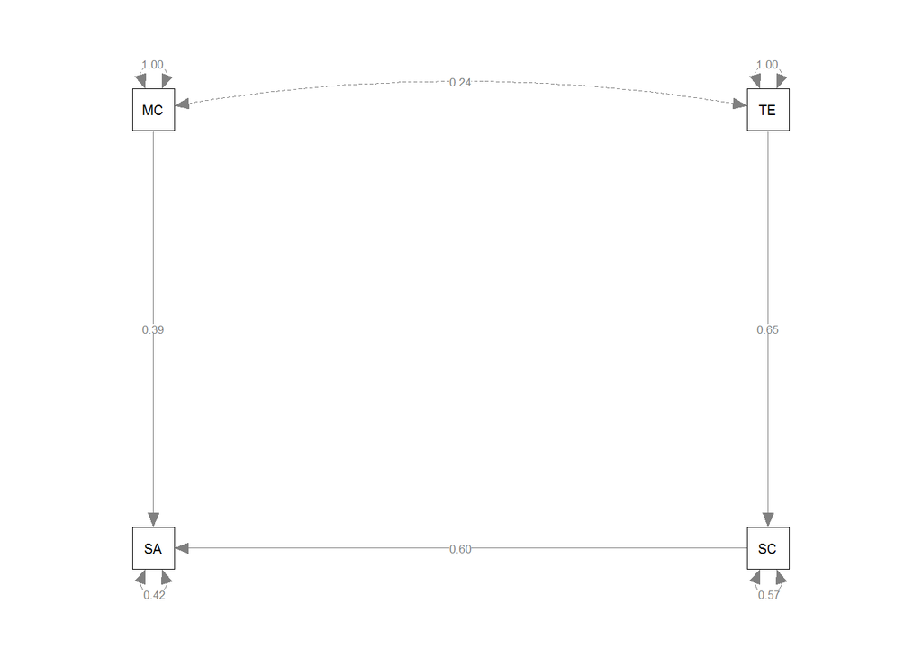

```r
semPaths(fit2,whatLabels = "std",layout = "tree")
```

#### Here we can see an improvement in CFI (.961) and RMSEA (0.159) although it stills bad

#### also all parameters are significant So, lets test if the difference between the two model is significant using the difference in X^2 and CFI and RMSEA

```r
anova(fit,fit2)
```

```
## Chi Square Difference Test
##
##      Df    AIC    BIC  Chisq Chisq diff Df diff Pr(>Chisq)
## fit   1 1155.3 1168.8 3.6870
## fit2  2 1149.6 1158.1 4.0109    0.32392       1     0.5693
```

#### The difference between the two model is not significant (P>.05) but we see a noticed improve in CFI(>.01) and TLI, so we will keep the most parsimonious and improved one (Fit2)